# GV903 Week 11

Maxmium Likelihood Estimation

Reddy

14/12/2021

# 1.

## 1.1. Binomial likelihood function with y heads, n trials, probability:

$$L(\pi|n,y)=\pi ^y(1-\pi)^{(n-y)}$$

## 1.2. Corresponding log likelihood:

$$\log L(\pi|n,y)=y· \log (pi)+(n-y)· \log (1-\pi)$$

## 1.3. Write this as an R function:

```r
binomial.loglikelihood<-function (prob,
y,n){
  loglikelihood<-y*log (prob) +(n-y)   *log (1-prob)
  return (loglikelihood)
}
```

## 1.4. Use the opt im function to optimize the likelihood given fixed y, n:

```r
test<-optim(c(.5),# starting value for prob
binomial.loglikelihood,#the log-likelihood function
method="BFGS",#optimization method
hessian=TRUE,# return numerical Hessian
control=list (fnscale=-1),# maximize instead of minimize
y=43, n=100)# the data
print (test)
```

```
## $par
## [1] 0.4300015
##
## $value
## [1] -68.33149
##
## $counts
## function gradient
##       13        4
##
## $convergence
## [1] 0
##
## $message
## NULL
##
## $hessian
##           [,1]
## [1,] -407.9996
```

## We can now proceed to compute the standard error(s):

```r
sqrt(diag(solve(-test$hessian)))
```

```
## [1] 0.0495074
```

## Only one parameter. It’s easy to plot the likelihood function:

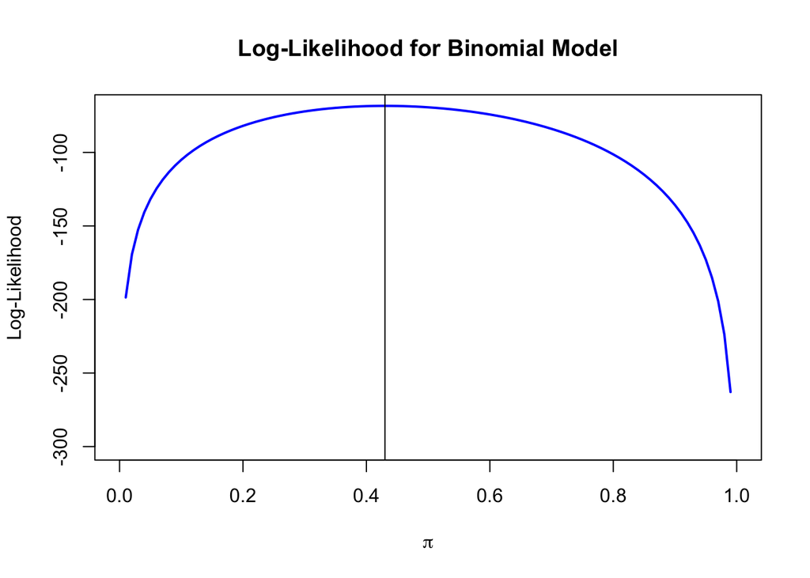

```r
ruler<-seq(0,1,0.01)
loglikelihood<- binomial.loglikelihood (ruler, y=43,n=100)
plot (ruler, loglikelihood, type="l",lwd=2, col="blue",
xlab=expression (pi), ylab="Log-Likelihood", ylim=c(-300, -70) ,main="Log-Likelihood for Binomial Model")
abline(v=.43)
```

# Week 11 Lab Exercises

Load the analyses you conducted in the lab in Week 9 using the populism dataset (acceptance.csv). The following exercises are based on these data and models.

## Task 1: Visualisation of results

Create a grouped boxplot with the `ggplot2` package in `R`. It should have one panel or facet for each scenario. In each panel or facet, there should be three boxes, one for left, one for centre, and one for right parties. The nine boxes overall should show the level of acceptance of decisions as a function of party type, grouped by scenario.

```r
acceptance <- read.csv("acceptance.csv")
head(acceptance)
```

```
##   X.1 X  id            scenario    decider acceptance agreement importance age
## 1   1 1 331 religious_education    experts -0.5000000         2          3  44
## 2   2 2 603        central_exam referendum  0.0000000         2          1  33
## 3   3 3 266      nuclear_energy        CDU -2.5000000         1          5  64
## 4   4 4 374        central_exam referendum -0.1666667         2          2  44
## 5   5 5 359 religious_education referendum -0.8333333         2          2  52
## 6   6 6 448      nuclear_energy        SPD -0.3333333         1          3  44
##   gender duration     trust     voter_influence big5_agreeableness
## 1   male      794 1.6666666    strong influence           3.666667
## 2   male      297 1.0000000      some influence           3.666667
## 3   male      931 0.3333333    strong influence           3.666667
## 4   male      632 0.6666667      some influence           2.666667
## 5 female      834 0.6666667 almost no influence           2.666667
## 6   male      491 0.3333333      some influence           3.000000
##   big5_extraversion big5_neuroticism big5_conscientiousness big5_openness
```

[output cut: 20 more lines]

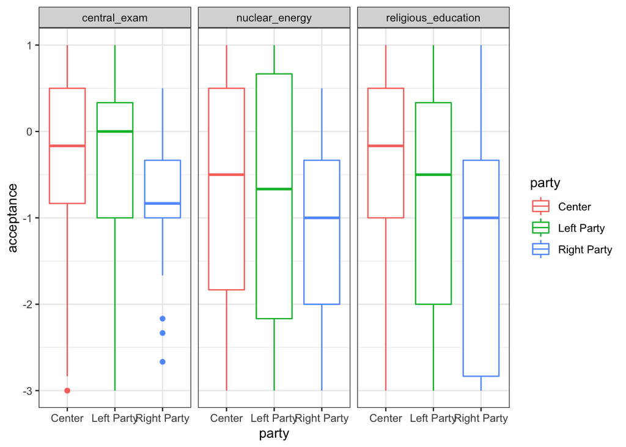

```r
acceptance %>%
  mutate(party=voting_pref)%>%
  mutate(party=ifelse(party=="Left Party","Left Party",
               ifelse(party=="DVU/REP/NPD","Right Party","Center"))) %>%
  ggplot(aes(party,acceptance))+
  geom_boxplot(aes(color=party))+
  facet_wrap(~scenario)+
  theme_bw()
```

```r
acceptance <- read.csv("acceptance.csv")
head(acceptance)
```

```
##   X.1 X  id            scenario    decider acceptance agreement importance age
## 1   1 1 331 religious_education    experts -0.5000000         2          3  44
## 2   2 2 603        central_exam referendum  0.0000000         2          1  33
## 3   3 3 266      nuclear_energy        CDU -2.5000000         1          5  64
## 4   4 4 374        central_exam referendum -0.1666667         2          2  44
## 5   5 5 359 religious_education referendum -0.8333333         2          2  52
## 6   6 6 448      nuclear_energy        SPD -0.3333333         1          3  44
##   gender duration     trust     voter_influence big5_agreeableness
## 1   male      794 1.6666666    strong influence           3.666667
## 2   male      297 1.0000000      some influence           3.666667
## 3   male      931 0.3333333    strong influence           3.666667
## 4   male      632 0.6666667      some influence           2.666667
## 5 female      834 0.6666667 almost no influence           2.666667
## 6   male      491 0.3333333      some influence           3.000000
##   big5_extraversion big5_neuroticism big5_conscientiousness big5_openness
```

[output cut: 20 more lines]

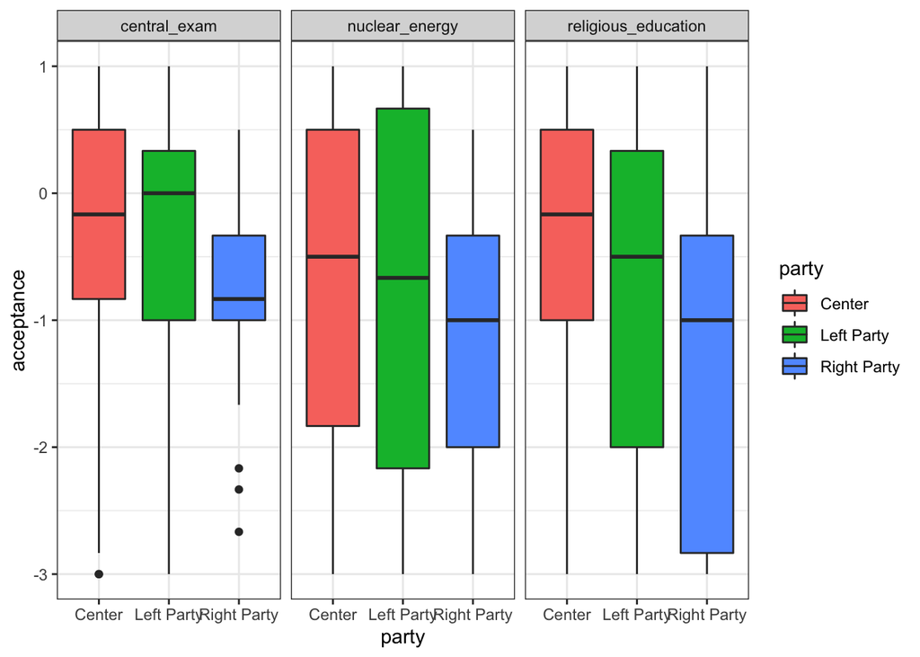

```r
acceptance %>%
  mutate(party=voting_pref)%>%
  mutate(party=ifelse(party=="Left Party","Left Party",
               ifelse(party=="DVU/REP/NPD","Right Party","Center"))) %>%
  ggplot(aes(party,acceptance,fill=party))+
  geom_boxplot()+
  facet_wrap(~scenario)+
  theme_bw()
```

## Task 2:Marginal effects

Create two separate subsets of the data: one for the central exam decision scenario and one for the religious education decision scenario. For each of the two subsets of the data, regress acceptance of the decision on agreement, importance, decider, right-wing party preference, voter influence, age, and an interaction effect between age and personal agreement with the decision. You can use a linear model. For each of the two models, create a marginal-effects plot for the interaction between age and agreement. You can use the `interplot` package for this purpose. Show the `R` code, model output, and diagram, and explain what you find in the diagrams, in conjunction with the model output. ### Central Exam

```r
sub_exam <- acceptance %>%
  filter(scenario=="central_exam") %>%
  mutate(right_pref=ifelse(voting_pref=="DVU/REP/NPD",1,0))
exam <- lm(acceptance~agreement + importance + decider +
    right_pref + voter_influence + age*agreement,sub_exam)
summary(exam)
```

```
##
## Call:
## lm(formula = acceptance ~ agreement + importance + decider +
##     right_pref + voter_influence + age * agreement, data = sub_exam)
##
## Residuals:
##      Min       1Q   Median       3Q      Max
## -2.64345 -0.34847  0.07115  0.39757  2.47781
##
## Coefficients:
##                                  Estimate Std. Error t value Pr(>|t|)
## (Intercept)                     -1.332168   0.252856  -5.268 1.92e-07 ***
## agreement                        0.553228   0.090700   6.100 1.91e-09 ***
## importance                      -0.167788   0.020821  -8.059 4.20e-15 ***
## deciderexperts                   0.078572   0.078720   0.998   0.3186
## deciderparty general             0.085044   0.080861   1.052   0.2933
## deciderreferendum                0.055587   0.080983   0.686   0.4927
## deciderSPD                       0.010547   0.082521   0.128   0.8983
## right_pref                      -0.400405   0.155940  -2.568   0.0105 *
## voter_influencedon't know       -0.092112   0.152281  -0.605   0.5455
## voter_influenceno response      -0.079620   0.187903  -0.424   0.6719
## voter_influencesome influence    0.076437   0.062232   1.228   0.2198
## voter_influencestrong influence  0.128382   0.073515   1.746   0.0813 .
## age                             -0.002357   0.005147  -0.458   0.6472
## agreement:age                    0.001591   0.001927   0.826   0.4092
## ---
## Signif. codes:  0 '***' 0.001 '**' 0.01 '*' 0.05 '.' 0.1 ' ' 1
##
## Residual standard error: 0.6271 on 599 degrees of freedom
## Multiple R-squared:  0.5174, Adjusted R-squared:  0.5069
## F-statistic: 49.39 on 13 and 599 DF,  p-value: < 2.2e-16
```

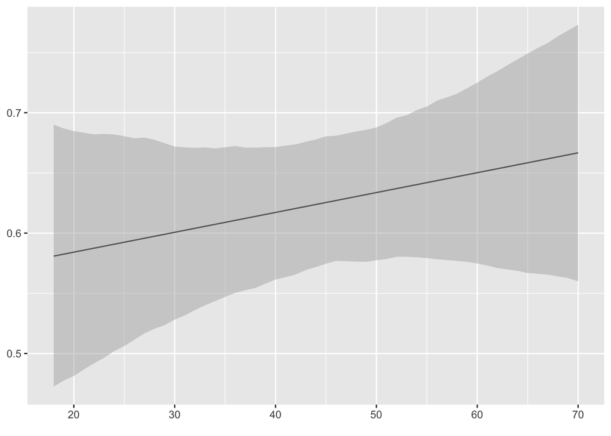

```r
interplot(exam, var2 = "age", var1 = "agreement")
```

### religious_education

```r
sub_educ <- acceptance %>%
  filter(scenario=="religious_education") %>%
  mutate(right_pref=ifelse(voting_pref=="DVU/REP/NPD",1,0))
educ <- lm(acceptance~agreement + importance + decider +
    right_pref + voter_influence + age*agreement,sub_educ)
summary(educ)
```

```
##
## Call:
## lm(formula = acceptance ~ agreement + importance + decider +
##     right_pref + voter_influence + age * agreement, data = sub_educ)
##
## Residuals:
##      Min       1Q   Median       3Q      Max
## -3.11122 -0.37931  0.09565  0.49084  3.03270
##
## Coefficients:
##                                  Estimate Std. Error t value Pr(>|t|)
## (Intercept)                     -1.246749   0.297900  -4.185 3.28e-05 ***
## agreement                        0.466017   0.101968   4.570 5.92e-06 ***
## importance                      -0.186214   0.024026  -7.751 3.94e-14 ***
## deciderexperts                  -0.011248   0.090576  -0.124 0.901216
## deciderparty general             0.152966   0.094008   1.627 0.104228
## deciderreferendum               -0.023862   0.092873  -0.257 0.797323
## deciderSPD                      -0.022874   0.095925  -0.238 0.811610
## right_pref                      -0.563327   0.182335  -3.090 0.002098 **
## voter_influencedon't know        0.344139   0.176789   1.947 0.052049 .
## voter_influenceno response      -0.102215   0.217479  -0.470 0.638527
## voter_influencesome influence    0.266110   0.071610   3.716 0.000221 ***
## voter_influencestrong influence  0.336054   0.083931   4.004 7.01e-05 ***
## age                             -0.011729   0.005896  -1.989 0.047106 *
## agreement:age                    0.004821   0.002147   2.245 0.025122 *
## ---
## Signif. codes:  0 '***' 0.001 '**' 0.01 '*' 0.05 '.' 0.1 ' ' 1
##
## Residual standard error: 0.725 on 599 degrees of freedom
## Multiple R-squared:  0.5604, Adjusted R-squared:  0.5508
## F-statistic: 58.73 on 13 and 599 DF,  p-value: < 2.2e-16
```

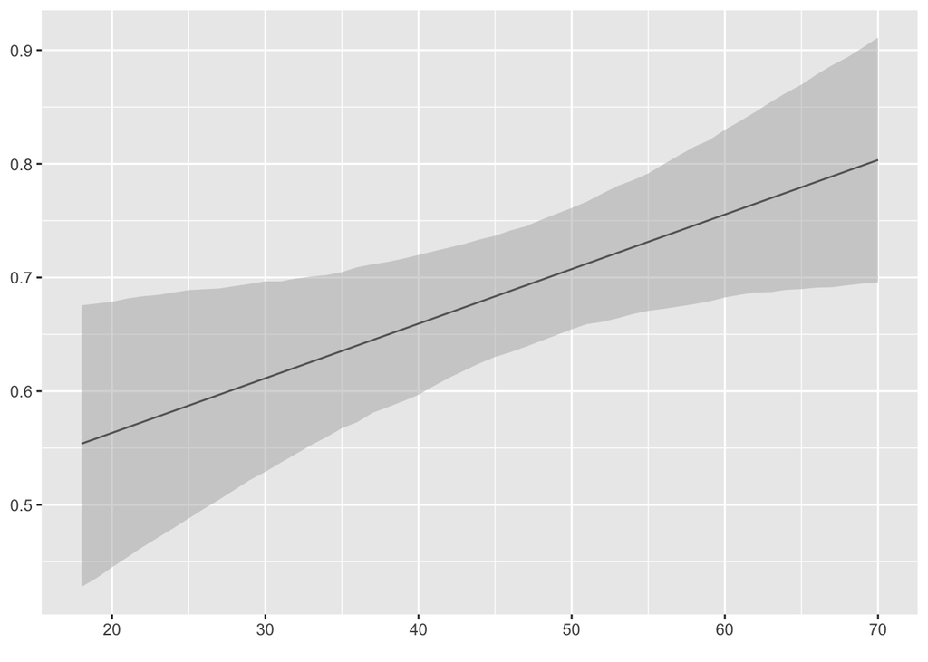

```r
interplot(educ, var2 = "age", var1 = "agreement")
```